# ggplot

There are 3 required components:

1. Data - The data you want to plot.
2. Mapping (aesthetic) - Tell R what you want to plot.
3. Geometric representation - Tell R what you want to see in the plot (i.e points, lines, diamonds).

To start, let’s load our library and get a dataset.

```r
library(tidyverse)

data()

Orange
```

```
   Tree  age circumference
1     1  118            30
2     1  484            58
3     1  664            87
4     1 1004           115
5     1 1231           120
6     1 1372           142
7     1 1582           145
8     2  118            33
9     2  484            69
10    2  664           111
11    2 1004           156
12    2 1231           172
13    2 1372           203
14    2 1582           203
```

[output cut: 21 more lines]

You’re probably wonder… I thought we were using `ggplot2`. We are… but as mentioned in the introduction to R section, the tidyverse ecosytem is quite resourceful - and include `ggplot2` and for this section, it also has datasets. I chose **Orange**.

Let’s run the first two important components…

# Data and Mapping

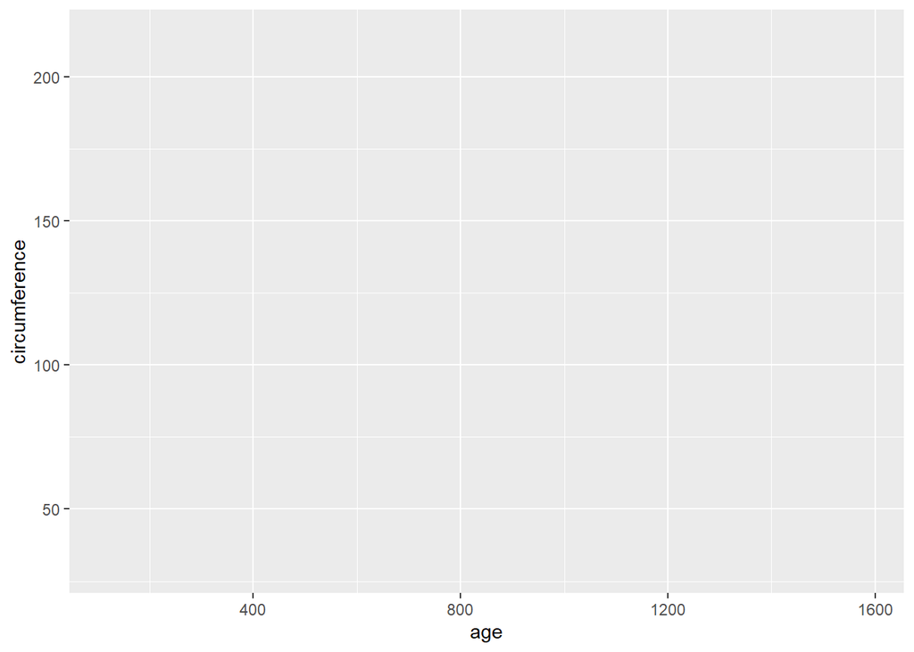

```r
ggplot(data = Orange,
       mapping = aes(x = age, y = circumference))
```

You will notice that the plot appears but there’s no values! The `mapping` function sets up your plot *canvas* (x and y axis) but we haven’t defined what you want to see in your plot.

# Geometric representation

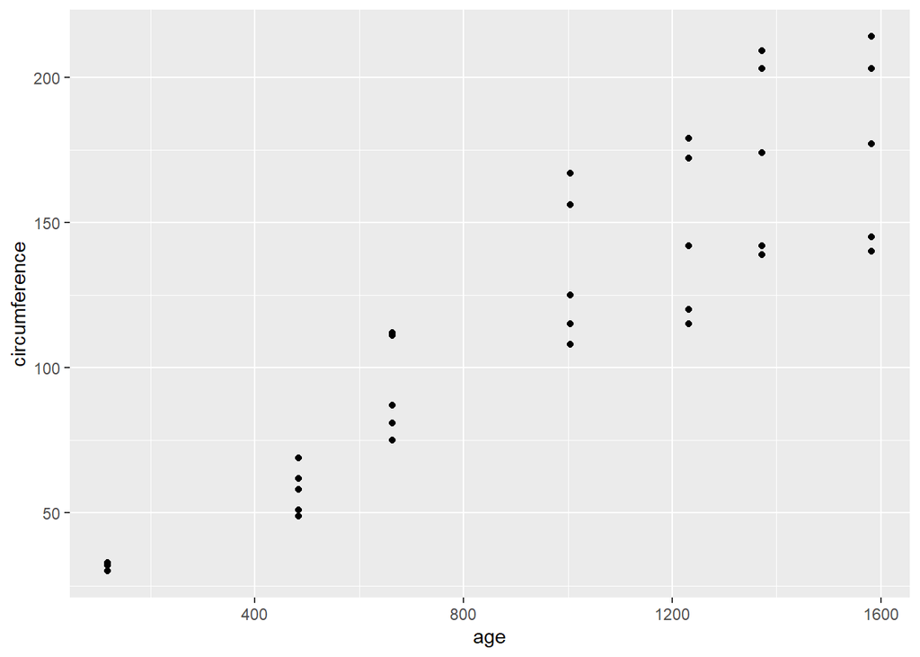

```r
ggplot(data = Orange,
       mapping = aes(x = age, y = circumference)) +
  geom_point()
```

Ah! some points are generated 🥳 But let’s add some customization…

## Size of points

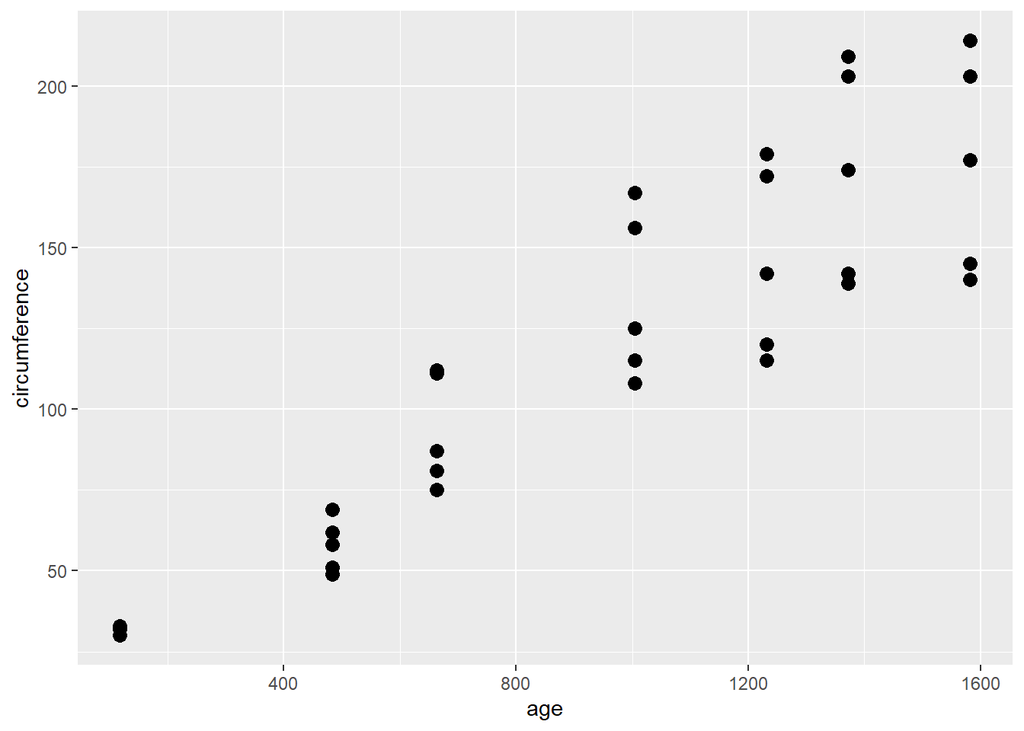

```r
ggplot(data = Orange,
       mapping = aes(x = age, y = circumference)) +
  geom_point(size = 3)
```

## Colour of points

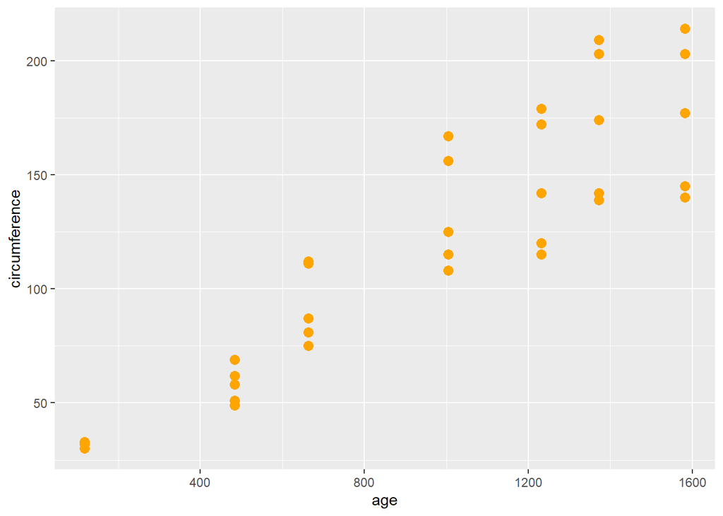

```r
ggplot(data = Orange,
       mapping = aes(x = age, y = circumference)) +
  geom_point(size = 3, color = "orange")
```

## Add a line

(i.e an additional geometric representation)

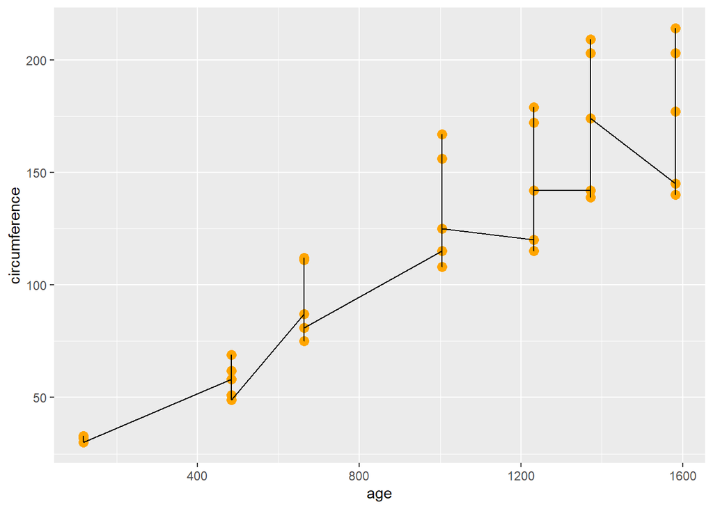

```r
ggplot(data = Orange,
       mapping = aes(x = age, y = circumference)) +
  geom_point(size = 3, color = "orange") +
  geom_line()
```

## Colour of line

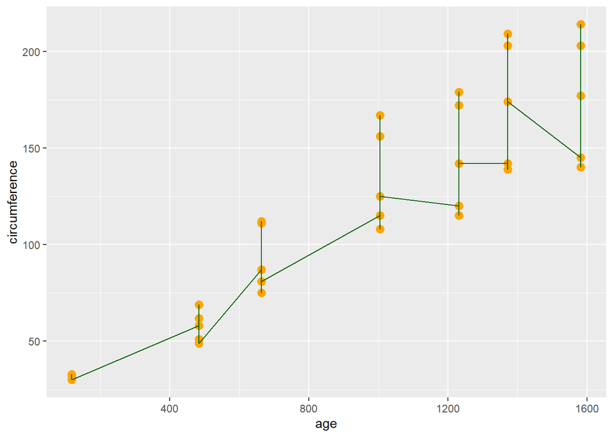

```r
ggplot(data = Orange,
       mapping = aes(x = age, y = circumference)) +
  geom_point(size = 3, color = "orange") +
  geom_line(color = "darkgreen")
```

We can even specify colour by a categorical variable! By applying the colour in `mapping()`, both `geom_point()` and `geom_line()` will be customized.

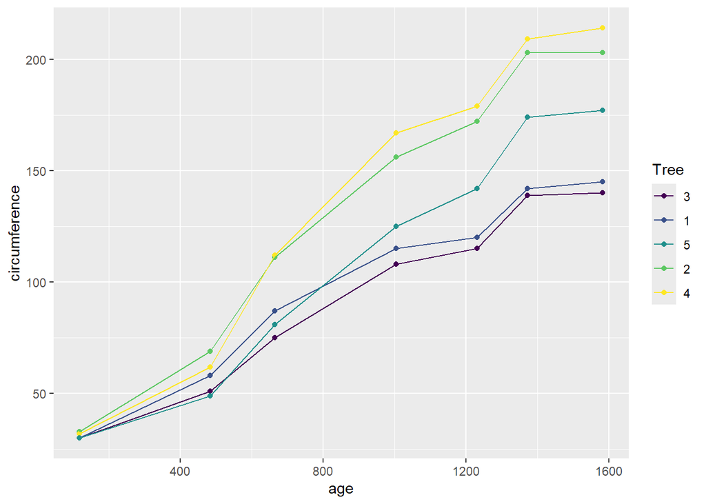

```r
ggplot(data = Orange,
       mapping = aes(x = age, y = circumference, color = Tree)) +
  geom_point() +
  geom_line()
```

Let’s say we want to specify colours for **Tree** categories…

We can do this 2 ways:

**1. Hard coding**

```r
ggplot(data = Orange,
       mapping = aes(x = age, y = circumference, color = Tree)) +
  geom_point() +
  geom_line() +
  scale_color_manual(
    values = c(
      "1" = "#F5276C",
      "2" = "darkorange",
      "3" = "blue",
      "4" = "purple",
      "5" = "black"
      )
    )
```

[output not shown]

**2. List**

```r
tree_cols <- c(
  "1" = "#F5276C",
  "2" = "darkorange",
  "3" = "blue",
  "4" = "purple",
  "5" = "black"
  )
ggplot(data = Orange,
       mapping = aes(x = age, y = circumference, color = Tree)) +
  geom_point() +
  geom_line() +
  scale_color_manual(values = tree_cols)
```

[output not shown]

Creating a **List** is a far more reproducible. It allows you to apply that same list to other `ggplot()` and the code is visually less daunting.

Now that we know how the important components work, let’s simplify the code a bit. The function is smart and knows what to expect in what order so we can remove things!

Let’s remove `data`, `mapping`, `x`, and `y` …

```r
ggplot(Orange,
       aes(age, circumference, color = Tree)) +
  geom_point() +
  geom_line() +
  scale_color_manual(values = tree_cols)
```

[output not shown]

# Layers🚧

This component is great for adding additional customization, including (but not limited to) trend lines, axis titles, legends, faceting (multiple plots by category), and other advanced formatting options.